# Métodos Quantitativos I

Lista VII: Modelos em painel: Tópicos Avançados

Professores: Daniel Grimaldi e Arthur Bragança

2026-01-14

```r
# loading required packages
if(!require(knitr)){install.packages("knitr")}
if(!require(devtools)){install.packages("devtools")}
if(!require(tidyverse)){install.packages("tidyverse")}
if(!require(magrittr)){install.packages("magrittr")}
if(!require(data.table)){install.packages("data.table")}
if(!require(haven)){install.packages("haven")}
if(!require(openxlsx)){install.packages("openxlsx")}
if(!require(stargazer)){install.packages("stargazer")}
if(!require(knitr)){install.packages("knitr")}
if(!require(kableExtra)){install.packages("kableExtra")}
if(!require(formatR)){install.packages("formatR")}
if(!require(extraDistr)){install.packages("extraDistr")}
if(!require(ggdag)){install.packages("ggdag")}
if(!require(mvtnorm)){install.packages("mvtnorm")}
if(!require(estimatr)){install.packages("estimatr")}
if(!require(modelsummary)){install.packages("modelsummary")}
if(!require(plm)){install.packages("plm")}
if(!require(stargazer)){install.packages("stargazer")}
source("https://raw.githubusercontent.com/dgrimald/Econometria_ENAP/refs/heads/main/Aula%209/pgd.R")
source("https://raw.githubusercontent.com/dgrimald/Econometria_ENAP/refs/heads/main/Tema%20Beamer/themes_enap.R")
```

## (1) Crie um caso teórico de avaliação de política pública

Dentro do *Chunk 1*, recrie exatamente a mesma base de dados usada para o **Caso 2 da Lista VI** (lembre-se de usar o mesmo set.seed usando na **Lista VI** para que os resultados sejam idênticos). Aqui essa base deverá receber o nome de **data_1**

**Chunk 1: Cria a amostra denominada data_1**

```r
set.seed(13)
data_1 <- pgd(
  n.id = 5000,
  n.t = 6,
  beta = c(0.5, -0.5),
  delta = -2,
  mu_x = c(200, 500),
  sigma_x = c(20, 80),
  mu_alpha = 25,
  sigma_alpha = 1,
  theta_1 = 0,
  theta_2 = 0,
  zeta = 1
)
head(data_1, 20)
```

```
## # A tibble: 20 × 15
##       id     t     y    x1    x2 alpha     P     s     D     v1     v2     v3
##    <int> <int> <dbl> <dbl> <dbl> <dbl> <dbl> <dbl> <int>  <dbl>  <dbl>  <dbl>
##  1     1     1  22.9  203.  503.  23.6     0 0.805     1  0.198  5.14  -0.349
##  2     2     1  32.3  207.  497.  26.2     0 0.228     0 -1.21  -4.72  -0.349
##  3     3     1  22.4  203.  503.  24.0     0 0.729     1 -1.83  -0.767 -0.349
##  4     4     1  22.9  206.  506.  25.4     0 0.395     1  0.228  3.69  -0.349
##  5     5     1  14.8  199.  513.  24.0     0 0.730     1  0.943  2.98  -0.349
##  6     6     1  17.3  195.  511.  25.0     0 0.502     1 -0.176  6.57  -0.349
##  7     7     1  26.6  195.  491.  25.0     0 0.508     0  1.37   7.19  -0.349
##  8     8     1  18.2  199.  510.  26.0     0 0.276     0  0.722 11.7   -0.349
##  9     9     1  27.0  206.  498.  23.3     0 0.850     1 -0.199 -2.42  -0.349
## 10    10     1  24.2  200.  504.  25.7     0 0.335     1  0.322 -1.94  -0.349
## 11    11     1  17.8  200.  515.  25.5     0 0.381     1 -0.686 -1.81  -0.349
## 12    12     1  35.7  201.  482.  25.4     0 0.397     0 -0.353 -8.70  -0.349
## 13    13     1  22.0  200.  508.  25.8     0 0.304     0 -2.59   6.51  -0.349
## 14    14     1  27.4  193.  488.  23.9     0 0.758     1 -0.213  6.25  -0.349
## 15    15     1  24.4  196.  494.  24.5     0 0.613     0  0.676  0.694 -0.349
## 16    16     1  14.8  199.  516.  24.9     0 0.536     1 -0.793  8.91  -0.349
## 17    17     1  27.6  197.  492.  25.6     0 0.364     0 -0.881 -3.30  -0.349
## 18    18     1  29.9  201.  491.  25.8     0 0.300     0  2.36  -3.58  -0.349
## 19    19     1  23.9  198.  499.  24.9     0 0.522     1 -0.651  0.859 -0.349
## 20    20     1  28.7  198.  492.  25.6     0 0.362     0  2.32  -0.333 -0.349
## # ℹ 3 more variables: e <dbl>, gamma <dbl>, pos <dbl>
```

### (2) Estimando o modelo TWFE por meio da transformação within

Usando o **Chunk 2**, crie uma função denominada **aplicar_within**. Essa função deve ter apenas 2 inputs: (i) **data.source**, que será um objeto do tipo data.frame; e (ii) nome_aluno, que você deverá preencher com seu nome. Esssa função será usada para estimar o impacto da política pública por meio dos seguintes modelos: TWFE_plm e TWFE_within.

A sua função terá exatamente 3 outputs: (i) *nome*, que será o nome do aluno; (ii) *data*, que é a base de dados usada para as estimativas; e (iii) *results*, que é um objeto do tipo lista que armazenará os resultados dos 2 modelos propostos.

Em seguinda, o **Chunk 2**, usará essa função sobre a base de dados criada no passo anterior (*Chunck 1*) e apresentará os resultados dos 2 modelos.

**Chunk 2: Estimando o impacto da política**

```r
aplicar_within <- function(nome, data.source=data_1){

  data.source %<>%
  group_by(id) %>%
  mutate(y_i = mean(y),
         x1_i = mean(x1),
         x2_i = mean(x2),
         P_i = mean(P)) %>%
  ungroup() %>%
  group_by(t) %>%
  mutate(y_t = mean(y),
         x1_t = mean(x1),
         x2_t = mean(x2),
         P_t = mean(P)) %>%
  ungroup() %>%
  mutate(y_within = (y - y_i) - y_t,
         x1_within = (x1 - x1_i) - x1_t,
         x2_within = (x2 - x2_i) - x2_t,
         P_within = (P - P_i) - P_t)

  reg_within <- lm(y_within ~ x1_within + x2_within + P_within, data=data.source)
  reg_plm <- plm(y ~ x1 + x2 + P, data = data.source, model = "within", effect = "twoways")

  # preparando objeto de saída da função
  return <- list("nome"=nome, "data"=data.source, "results"=list("twfe_plm"=reg_plm, "twfe_within"= reg_within))
}
```

**Chunk 3: Resultados**

```r
estimativas <- aplicar_within(nome="Daniel Grimaldi", data.source=data_1)
estimativas$nome
```

```
## [1] "Daniel Grimaldi"
```

```r
head(estimativas$data)
```

```
## # A tibble: 6 × 27
##      id     t     y    x1    x2 alpha     P     s     D     v1     v2     v3
##   <int> <int> <dbl> <dbl> <dbl> <dbl> <dbl> <dbl> <int>  <dbl>  <dbl>  <dbl>
## 1     1     1  22.9  203.  503.  23.6     0 0.805     1  0.198  5.14  -0.349
## 2     2     1  32.3  207.  497.  26.2     0 0.228     0 -1.21  -4.72  -0.349
## 3     3     1  22.4  203.  503.  24.0     0 0.729     1 -1.83  -0.767 -0.349
## 4     4     1  22.9  206.  506.  25.4     0 0.395     1  0.228  3.69  -0.349
## 5     5     1  14.8  199.  513.  24.0     0 0.730     1  0.943  2.98  -0.349
## 6     6     1  17.3  195.  511.  25.0     0 0.502     1 -0.176  6.57  -0.349
## # ℹ 15 more variables: e <dbl>, gamma <dbl>, pos <dbl>, y_i <dbl>, x1_i <dbl>,
## #   x2_i <dbl>, P_i <dbl>, y_t <dbl>, x1_t <dbl>, x2_t <dbl>, P_t <dbl>,
## #   y_within <dbl>, x1_within <dbl>, x2_within <dbl>, P_within <dbl>
```

```r
summary(estimativas$results$twfe_plm)
```

```
## Twoways effects Within Model
##
## Call:
## plm(formula = y ~ x1 + x2 + P, data = data.source, effect = "twoways",
##     model = "within")
##
## Balanced Panel: n = 5000, T = 6, N = 30000
##
## Residuals:
##       Min.    1st Qu.     Median    3rd Qu.       Max.
## -3.5724044 -0.6170890  0.0012124  0.6059000  3.8859159
##
## Coefficients:
##      Estimate Std. Error  t-value  Pr(>|t|)
## x1  0.4928016  0.0062862   78.395 < 2.2e-16 ***
## x2 -0.4984019  0.0012806 -389.196 < 2.2e-16 ***
## P  -1.9946745  0.0230768  -86.436 < 2.2e-16 ***
## ---
## Signif. codes:  0 '***' 0.001 '**' 0.01 '*' 0.05 '.' 0.1 ' ' 1
##
## Total Sum of Squares:    190180
## Residual Sum of Squares: 24947
## R-Squared:      0.86883
## Adj. R-Squared: 0.84255
## F-statistic: 55177.8 on 3 and 24992 DF, p-value: < 2.22e-16
```

```r
summary(estimativas$results$twfe_within)
```

```
##
## Call:
## lm(formula = y_within ~ x1_within + x2_within + P_within, data = data.source)
##
## Residuals:
##     Min      1Q  Median      3Q     Max
## -3.5724 -0.6171  0.0012  0.6059  3.8859
##
## Coefficients:
##               Estimate Std. Error t value Pr(>|t|)
## (Intercept) -1.749e+02  1.293e+00 -135.28   <2e-16 ***
## x1_within    4.928e-01  5.738e-03   85.89   <2e-16 ***
## x2_within   -4.984e-01  1.169e-03 -426.38   <2e-16 ***
## P_within    -1.995e+00  2.106e-02  -94.69   <2e-16 ***
## ---
## Signif. codes:  0 '***' 0.001 '**' 0.01 '*' 0.05 '.' 0.1 ' ' 1
##
## Residual standard error: 0.912 on 29996 degrees of freedom
## Multiple R-squared:  0.8688, Adjusted R-squared:  0.8688
## F-statistic: 6.623e+04 on 3 and 29996 DF,  p-value: < 2.2e-16
```

### (3) Demonstre que a estimativa obtida por meio da transformação within está centrado em torno do parâmetro populacional verdadeiro

Usando o Chunk 4, replique o gráfico apresentado no slide 22 da Aula 9, mas usando como referência os 2 modelos estimados na etapa (2) dessa lista. Lembre-se de traçar a linha vertical no valor verdadeiro de $\delta$ definido pelo seu PGD.

**Chunk 4: Gráfico com distribuição das estimativas**

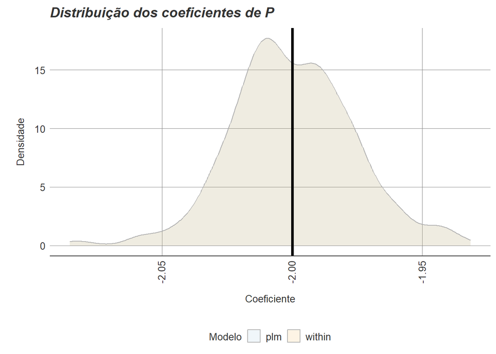

```r
# constroi função para replicação
get_models <- function(i){

  # define seed
  set.seed(i)

  # cria base de dados
  data_i <- pgd(
    n.id = 5000,
    n.t = 6,
    beta = c(0.5, -0.5),
    delta = -2,
    mu_x = c(200, 500),
    sigma_x = c(20, 80),
    mu_alpha = 25,
    sigma_alpha = 1,
    theta_1 = 0,
    theta_2 = 0,
    zeta = 1)

  # aplica transformação within
  data_i %<>%
  group_by(id) %>%
  mutate(y_i = mean(y),
         x1_i = mean(x1),
         x2_i = mean(x2),
         P_i = mean(P)) %>%
  ungroup() %>%
  group_by(t) %>%
  mutate(y_t = mean(y),
         x1_t = mean(x1),
         x2_t = mean(x2),
         P_t = mean(P)) %>%
  ungroup() %>%
  mutate(y_within = (y - y_i) - y_t,
         x1_within = (x1 - x1_i) - x1_t,
         x2_within = (x2 - x2_i) - x2_t,
         P_within = (P - P_i) - P_t)

  # estima modelos
  reg_within <- lm(y_within ~ x1_within + x2_within + P_within, data=data_i)
  reg_plm <- plm(y ~ x1 + x2 + P, data = data_i, model = "within", effect = "twoways")

  # salva resultados
  output <- data.frame(sample=i,
                       plm = reg_plm$coefficients["P"],
                       within = reg_within$coefficients["P_within"])}

# aplica função
lgn.data <- lapply(1:500, get_models) %>%
  rbindlist()

# organiza resultados
data.temp <- lgn.data %>%
  pivot_longer(cols=c("plm", "within"),
               names_to = "model",
               values_to = "coef")

# gera figura
fig <- ggplot(data.temp) +
  geom_density(aes(coef, fill=as.factor(model)),
               alpha=0.1,
               color=cores$cinza_claro) +
  scale_fill_manual(values=c(cores$azul_escuro, cores$amarelo_escuro)) +
  geom_vline(xintercept = -2, color=cores$preto, linewidth=1.3) +
  labs(title="Distribuição dos coeficientes de P",
       y="Densidade",
       x="Coeficiente",
       fill="Modelo") +
  tema_base_fundobranco()
fig
```